# Causality: The Anchoring Effect and Experimental Design

Quantitative Methods for Humanities

CUNEF Universidad, 2024

# Introduction

The **anchoring effect** is a classic example of how irrelevant information can skew human judgment. Here, we revisit this bias using data from the ManyLabs replication project, which asked participants to estimate the height of Mount Everest after being exposed to a “high” or “low” anchor value.

# Research Design

Before analyzing the data, we clarify the structure of the experiment.

## Q1. Treatment vs Outcome

- **Treatment variable:** `anchor` (randomly assigned: “low” or “high”).
- **Outcome variable:** `everest_feet`, the participant’s numerical estimate of Everest’s height.

## Q2. Threats to Internal Validity

Two key concerns could undermine internal validity:

1. **Contamination**: Participants may talk to each other, specially in the online setting.
2. **Different treatment versions**: The lab setting, timing, and other factors may differ among different sessions.

# Data Setup

## Q3. Load Data and Inspect Randomization

```r
load("anchoring.RData")
head(anchoring)
```

```
##   session_id sex age citizenship referrer us_or_international lab_or_online
## 1    2400853   f  18          US abington                  US        In-lab
## 2    2400856   f  19          CN abington                  US        In-lab
## 3    2400860   f  18          US abington                  US        In-lab
## 4    2400868   m  18          US abington                  US        In-lab
## 5    2400914   f  18          US abington                  US        In-lab
## 6    2400916   f  18          US abington                  US        In-lab
##   anchor everest_feet everest_meters
## 1   high        30000             NA
## 2   high        30000             NA
## 3    low         5000             NA
## 4    low         2400             NA
## 5    low        10000             NA
## 6   high        25000             NA
```

```r
summary(anchoring)
```

```
##    session_id          sex                 age        citizenship
##  Min.   : 619630   Length:4632        Min.   :15.00   Length:4632
##  1st Qu.:2411800   Class :character   1st Qu.:19.00   Class :character
##  Median :2432910   Mode  :character   Median :21.00   Mode  :character
##  Mean   :2436343                      Mean   :25.44
##  3rd Qu.:2476985                      3rd Qu.:28.00
##  Max.   :2511223                      Max.   :85.00
##                                       NA's   :5
##    referrer         us_or_international lab_or_online         anchor
##  Length:4632        Length:4632         Length:4632        Length:4632
##  Class :character   Class :character    Class :character   Class :character
##  Mode  :character   Mode  :character    Mode  :character   Mode  :character
##
##
##
##
##   everest_feet   everest_meters
##  Min.   : 2001   Min.   :  610
##  1st Qu.: 5905   1st Qu.: 2478
##  Median :26246   Median : 8000
##  Mean   :22705   Mean   : 6637
##  3rd Qu.:37000   3rd Qu.: 8887
##  Max.   :45499   Max.   :13867
##                  NA's   :3981
```

Let’s inspect whether treatment groups are balanced in age and sex, separately for lab and online participants.

```r
table(anchoring$lab_or_online)
```

```
##
## In-lab Online
##   2197   2435
```

```r
# Subsetting the data into lab and online
online <- subset(anchoring, lab_or_online == "Online")
lab <- subset(anchoring, lab_or_online == "In-lab")

# Age, gender, and citizenchip by anchor (online only)
tapply(online$age, online$anchor, mean, na.rm = TRUE)
```

```
##     high      low
## 29.96560 30.23245
```

```r
tapply(online$sex, online$anchor, function(x) prop.table(table(x)))
```

```
## $high
## x
##            .            f            m
## 0.0008368201 0.6100418410 0.3891213389
##
## $low
## x
##            .            f            m
## 0.0008064516 0.6354838710 0.3637096774
```

```r
# Age, gender, and citizenchip by anchor (lab only)
tapply(lab$age, lab$anchor, mean, na.rm = TRUE)
```

```
##     high      low
## 20.32952 20.24084
```

```r
tapply(lab$sex, lab$anchor, function(x) prop.table(table(x)))
```

```
## $high
## x
##           .           f           m
## 0.000952381 0.730476190 0.268571429
##
## $low
## x
##            .            f            m
## 0.0008718396 0.7096774194 0.2894507411
```

Lets visualize it

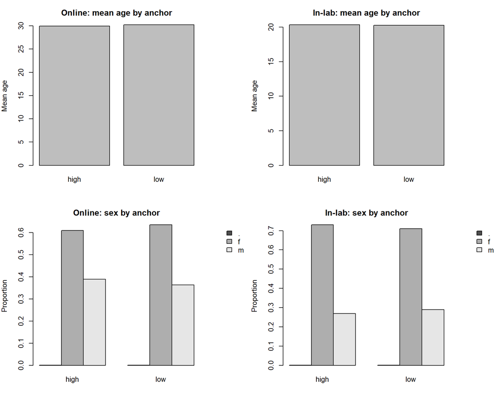

```r
par(mfrow = c(2, 2), mar = c(4, 4, 3, 6), xpd = TRUE)

# Mean age by anchor
barplot(tapply(online$age, online$anchor, mean, na.rm = TRUE),
        main = "Online: mean age by anchor",
        ylab = "Mean age")

barplot(tapply(lab$age, lab$anchor, mean, na.rm = TRUE),
        main = "In-lab: mean age by anchor",
        ylab = "Mean age")

# Sex proportions by anchor
barplot(prop.table(table(online$sex, online$anchor), 2),
        beside = TRUE,
        main = "Online: sex by anchor",
        ylab = "Proportion",
        legend.text = rownames(prop.table(table(online$sex, online$anchor), 2)),
        args.legend = list(x = "topright", inset = c(-0.28, 0), bty = "n"))

barplot(prop.table(table(lab$sex, lab$anchor), 2),
        beside = TRUE,
        main = "In-lab: sex by anchor",
        ylab = "Proportion",
        legend.text = rownames(prop.table(table(lab$sex, lab$anchor), 2)),
        args.legend = list(x = "topright", inset = c(-0.28, 0), bty = "n"))
```

```r
par(mfrow = c(1, 1), xpd = FALSE)
```

What about citizenship distribution?

```r
# Age, gender, and citizenchip by anchor (online only)
tapply(online$citizenship, online$anchor, function(x) prop.table(table(x)))
```

```
## $high
## x
##            .           AU           BR           CA           CN           CO
## 0.0041841004 0.0016736402 0.0008368201 0.0033472803 0.0008368201 0.0016736402
##           CV           FR           IN           IR           IT           JP
## 0.0008368201 0.0008368201 0.0142259414 0.0008368201 0.0376569038 0.0008368201
##           KE           KR           LA           MH           MX           MY
## 0.0016736402 0.0016736402 0.0008368201 0.0008368201 0.0016736402 0.0008368201
##           NG           NP        other           PE           PL           RU
## 0.0008368201 0.0008368201 0.0016736402 0.0008368201 0.0535564854 0.0008368201
##           TR           UG           UK           US
## 0.0326359833 0.0008368201 0.0025104603 0.8301255230
##
## $low
## x
##            .           AL           BO           CA           CO           FI
## 0.0024193548 0.0008064516 0.0008064516 0.0040322581 0.0008064516 0.0008064516
##           IE           IN           IT           KR           LK           MK
## 0.0008064516 0.0185483871 0.0451612903 0.0016129032 0.0008064516 0.0008064516
##           MX           NG           NI           PA           PL           PW
## 0.0008064516 0.0008064516 0.0008064516 0.0008064516 0.0580645161 0.0008064516
##           RU           TR           TW           US           VN
## 0.0008064516 0.0282258065 0.0008064516 0.8298387097 0.0008064516
```

```r
# Age, gender, and citizenchip by anchor (lab only)
tapply(lab$citizenship, lab$anchor, function(x) prop.table(table(x)))
```

```
## $high
## x
##          AF          BE          BG          BR          CA          CN
## 0.002857143 0.001904762 0.000952381 0.032380952 0.056190476 0.024761905
##          CO          CZ          DE          DK          DM          DO
## 0.001904762 0.003809524 0.002857143 0.002857143 0.000952381 0.000952381
##          ES          FR          GH          GR          HK          HN
## 0.000952381 0.003809524 0.000952381 0.001904762 0.008571429 0.000952381
##          HT          IE          IL          IN          IT          JM
## 0.001904762 0.000952381 0.000952381 0.014285714 0.003809524 0.000952381
##          JP          KE          KR          LT          MX          MY
## 0.001904762 0.000952381 0.012380952 0.000952381 0.001904762 0.010476190
##          NG          NL          NP          PE          PH          PK
## 0.001904762 0.017142857 0.000952381 0.000952381 0.001904762 0.003809524
##          PL          PR          PT          RO          RU          SA
## 0.018095238 0.000952381 0.000952381 0.000952381 0.002857143 0.001904762
##          SE          SG          SK          TH          TR          TW
## 0.002857143 0.013333333 0.001904762 0.000952381 0.000952381 0.000952381
##          UK          US          VN
## 0.034285714 0.687619048 0.003809524
##
## $low
## x
##            .           AF           AL           AO           AT           AU
## 0.0008718396 0.0008718396 0.0008718396 0.0008718396 0.0008718396 0.0008718396
##           BD           BE           BM           BR           BS           CA
## 0.0017436792 0.0008718396 0.0008718396 0.0401046207 0.0008718396 0.0680034874
##           CL           CM           CN           CO           CZ           DE
## 0.0008718396 0.0008718396 0.0340017437 0.0008718396 0.0034873583 0.0017436792
##           DK           EC           ES           FI           FR           GH
## 0.0026155187 0.0017436792 0.0017436792 0.0008718396 0.0052310375 0.0008718396
##           GR           GT           GY           HK           ID           IL
## 0.0008718396 0.0008718396 0.0026155187 0.0043591979 0.0008718396 0.0008718396
##           IN           IT           JP           KE           KR           KW
## 0.0113339146 0.0017436792 0.0017436792 0.0008718396 0.0104620750 0.0017436792
##           LT           MA           MO           MX           MY           NG
## 0.0017436792 0.0008718396 0.0008718396 0.0034873583 0.0165649520 0.0017436792
##           NL           PH           PK           PL           PT           PY
## 0.0401046207 0.0017436792 0.0017436792 0.0348735833 0.0026155187 0.0008718396
##           RO           RU           SG           SV           TH           TR
## 0.0008718396 0.0008718396 0.0087183958 0.0008718396 0.0026155187 0.0017436792
##           TW           UA           UG           UK           US           UZ
## 0.0043591979 0.0008718396 0.0008718396 0.0252833479 0.6294681779 0.0008718396
##           VG           VN           ZA           ZM
## 0.0008718396 0.0017436792 0.0008718396 0.0008718396
```

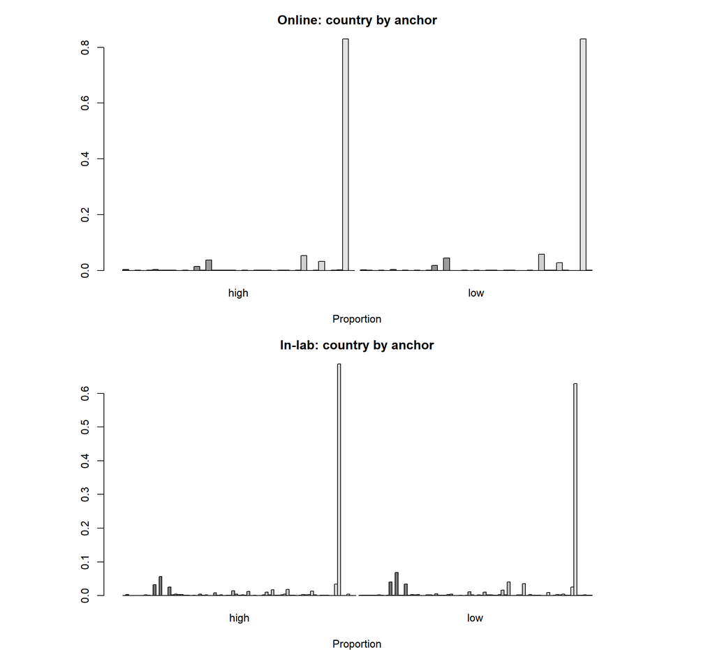

```r
# Plot
par(mfrow = c(2, 1), mar = c(4, 8, 3, 8), xpd = TRUE)

# Country distribution by anchor: online (log1 scale)
barplot(prop.table(table(online$citizenship, online$anchor), 2),
        beside = TRUE,
        main = "Online: country by anchor",
        xlab = "Proportion",
        legend.text = rownames(prop.table(table(online$citizenship, online$anchor), 2)),
        args.legend = list(x = "topright", inset = c(-0.35, 0), bty = "n", cex = 0.8))

# Country distribution by anchor: lab (log1 scale)
barplot(prop.table(table(lab$citizenship, lab$anchor), 2),
        beside = TRUE,
        main = "In-lab: country by anchor",
        xlab = "Proportion",
        legend.text = rownames(prop.table(table(lab$citizenship, lab$anchor), 2)),
        args.legend = list(x = "topright", inset = c(-0.35, 0), bty = "n", cex = 0.8))
```

```r
par(mfrow = c(1, 1), xpd = FALSE)
```

**Interpretation:** If randomization holds, age and sex distributions should be similar across the “low” and “high” anchor groups.

# Causal Estimation

## Q4. Estimating the Causal Effect

If the random assignment to anchor groups holds (especially in the lab), the **difference in means** between groups is likely to be an **unbiased estimator** of the causal effect of anchoring.

We compute it next.

## Q5. Judged Everest Height by Anchor

```r
tapply(anchoring$everest_feet, anchoring$anchor, mean, na.rm = TRUE)
```

```
##     high      low
## 34607.88 11510.55
```

Let’s compute the **standard deviation** to contextualize the mean difference.

```r
sd(anchoring$everest_feet, na.rm = TRUE)
```

```
## [1] 15142.44
```

## Q6. Interpretation

### Formal Hypothesis Test (Beyond the scope of this course)

We can formally test whether the difference in means between the two anchor groups is statistically significant using a two-sample *t-test*. Here’s the code and result:

```r
# Two-sample t-test for judged Everest height
t.test(everest_feet ~ anchor, data = anchoring)
```

```
##
##  Welch Two Sample t-test
##
## data:  everest_feet by anchor
## t = 80.392, df = 4625.6, p-value < 2.2e-16
## alternative hypothesis: true difference in means between group high and group low is not equal to 0
## 95 percent confidence interval:
##  22534.07 23660.60
## sample estimates:
## mean in group high  mean in group low
##           34607.88           11510.55
```

To assess statistical significance, we perform a two-sample *t-test* comparing the Everest height estimates across the two anchor conditions:

- **Null hypothesis** ($H_0$): The mean judged height is the same in both groups.
- **Alternative hypothesis** ($H_A$): The means differ between the groups.

The test yields a p-value close to zero (well below any conventional threshold such as 0.05), so we **reject the null hypothesis**. This confirms that the anchoring treatment caused a statistically significant shift in estimated heights.

# Causal Interpretation

## Q7. Can We Infer Causality?

If we believe that the **anchor assignment was random**, and no confounding factors affected both the anchor and the response, then **yes**, we can interpret the effect as causal.

Otherwise, we risk attributing to the anchor what could be due to unobserved participant differences (e.g., prior knowledge, different versions of the treatment, etc).

# External Validity

## Q8. Generalizability Across Countries

Even in well-run experiments, **external validity** can be limited. Let’s compare estimates across countries:

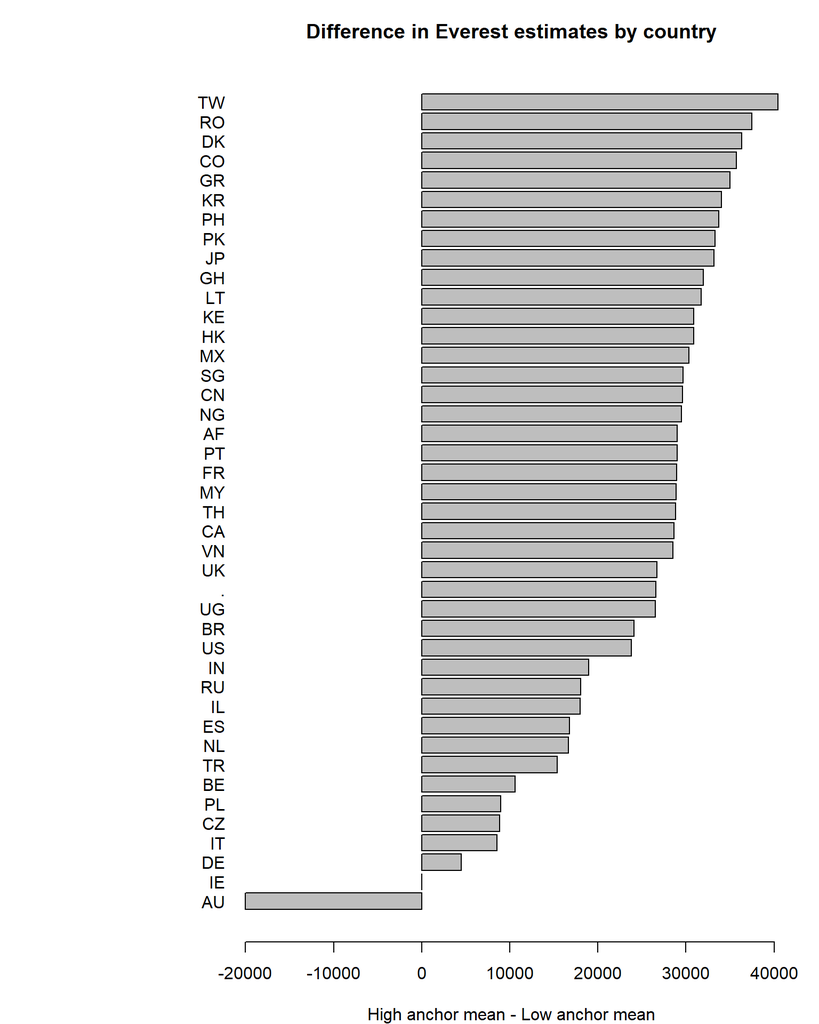

```r
# Get unique countries
countries <- unique(anchoring$citizenship)

# Initialize vector
diff_means <- numeric(length(countries))
names(diff_means) <- countries

# Loop over countries and compute difference (High - Low)
for (c in countries) {
  sub <- anchoring[anchoring$citizenship == c, ]
  m_high <- mean(sub$everest_feet[sub$anchor == "high"], na.rm = TRUE)
  m_low  <- mean(sub$everest_feet[sub$anchor == "low"], na.rm = TRUE)
  diff_means[c] <- m_high - m_low
}

# Remove NAs and sort
diff_means <- diff_means[!is.na(diff_means)]
diff_means <- sort(diff_means)

# Horizontal barplot
par(mar = c(4, 12, 3, 2))
barplot(diff_means,
        horiz = TRUE,
        las = 1,
        main = "Difference in Everest estimates by country",
        xlab = "High anchor mean - Low anchor mean")
```

As we see, average estimates of Everest’s height vary widely by country. Cultural, educational, or even language differences can influence how participants interpret the same task. This underscores the challenge of **generalizing experimental findings** globally.

# Final Thoughts

This case is a classic illustration of experimental design in action. It shows how randomized experiments, even when simple, can identify **causal mechanisms** behind human behavior. However, the power of such studies depends on thoughtful design, faithful implementation, and careful consideration of external and internal threats to validity.

# Exercises

- Recompute the anchoring effect **only for lab participants**.
- Compare the magnitude of the effect **between sexes**.
- Visualize the distribution of estimates using a histogram or boxplot.
- Conduct a **t-test** to assess the statistical significance of the effect.